# Tidyverse CREATE

Miguel Gomez

04-07-2023

```r
library(tidyverse)
library(reactable)
library(janitor)
```

— Due to the ongoing climate surrounding police interactions with civilians, I decided to review the article “Where Police Have Killed Americans In 2015” by Ben Casselman. This articles focuses on the demographic and economic information of the neighborhoods where these police killings occurred.

Link:https://fivethirtyeight.com/features/where-police-have-killed-americans-in-2015/

—

Pulling Data

```r
data1<-read.csv("https://raw.githubusercontent.com/fivethirtyeight/data/master/police-killings/police_killings.csv")
head(data1)
```

```
##                 name age gender   raceethnicity    month day year
## 1 A'donte Washington  16   Male           Black February  23 2015
## 2     Aaron Rutledge  27   Male           White    April   2 2015
## 3        Aaron Siler  26   Male           White    March  14 2015
## 4       Aaron Valdez  25   Male Hispanic/Latino    March  11 2015
## 5       Adam Jovicic  29   Male           White    March  19 2015
## 6      Adam Reinhart  29   Male           White    March   7 2015
##            streetaddress         city state latitude  longitude state_fp
## 1           Clearview Ln    Millbrook    AL 32.52958  -86.36283        1
## 2 300 block Iris Park Dr    Pineville    LA 31.32174  -92.43486       22
## 3   22nd Ave and 56th St      Kenosha    WI 42.58356  -87.83571       55
## 4      3000 Seminole Ave   South Gate    CA 33.93930 -118.21946        6
## 5         364 Hiwood Ave Munroe Falls    OH 41.14857  -81.42988       39
## 6    18th St and Palm Ln      Phoenix    AZ 33.46938 -112.04332        4
##   county_fp tract_ce      geo_id county_id             namelsad
```

[output cut: 27 more lines]

```r
data2 <- as.data.frame(data1)
glimpse(data2)
```

```
## Rows: 467
## Columns: 34
## $ name                 <chr> "A'donte Washington", "Aaron Rutledge", "Aaron Si…
## $ age                  <chr> "16", "27", "26", "25", "29", "29", "22", "35", "…
## $ gender               <chr> "Male", "Male", "Male", "Male", "Male", "Male", "…
## $ raceethnicity        <chr> "Black", "White", "White", "Hispanic/Latino", "Wh…
## $ month                <chr> "February", "April", "March", "March", "March", "…
## $ day                  <int> 23, 2, 14, 11, 19, 7, 27, 26, 28, 7, 26, 12, 20, …
## $ year                 <int> 2015, 2015, 2015, 2015, 2015, 2015, 2015, 2015, 2…
## $ streetaddress        <chr> "Clearview Ln", "300 block Iris Park Dr", "22nd A…
## $ city                 <chr> "Millbrook", "Pineville", "Kenosha", "South Gate"…
## $ state                <chr> "AL", "LA", "WI", "CA", "OH", "AZ", "CA", "CA", "…
## $ latitude             <dbl> 32.52958, 31.32174, 42.58356, 33.93930, 41.14857,…
## $ longitude            <dbl> -86.36283, -92.43486, -87.83571, -118.21946, -81.…
## $ state_fp             <int> 1, 22, 55, 6, 39, 4, 6, 6, 48, 26, 6, 6, 48, 18, …
```

[output cut: 21 more lines]

—

## Selecting ethnicity data

```r
raceethnicitycounts <- table(data2$raceethnicity)
```

—

## Counts how many times each ethnicity shows up

```r
raceethnicitycounts
```

```
##
## Asian/Pacific Islander                  Black        Hispanic/Latino
##                     10                    135                     67
##        Native American                Unknown                  White
##                      4                     15                    236
```

—

## Labels for ethnicities

```r
raceethnicitycountslabels <- c("Asian/Pacific Islander", "Black", "Hispanic/Latino", "Native American",  "Unknown",  "White")
```

—

## Calculates ethnicity counts percentages

```r
raceethnicitycountsratio <- raceethnicitycounts/sum(raceethnicitycounts)
```

—

## Converts ethnicity counts to percentages

```r
pct <- round(raceethnicitycountsratio/sum(raceethnicitycountsratio)*100)
```

—

## Adds percentages to labels

```r
raceethnicitycountslabels <- paste(raceethnicitycountslabels, pct)
```

—

## Adds % to labels

```r
raceethnicitycountslabels  <- paste(raceethnicitycountslabels, "%", sep="")
```

— This graph breaks down the people killed by ethnicity. —

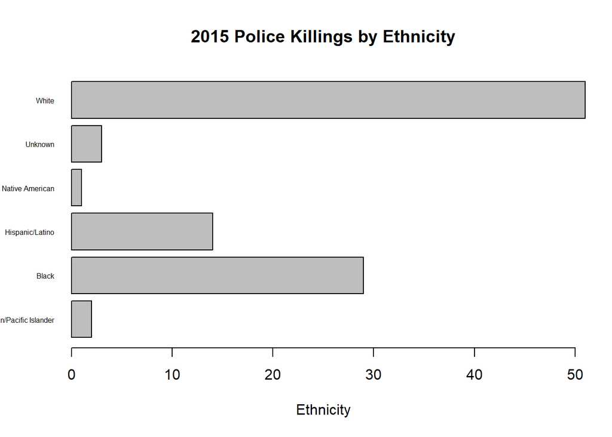

```r
barplot(pct, horiz=T, xlim = c(0,50) ,las=1,  main = "2015 Police Killings by Ethnicity", xlab= "Ethnicity",  cex.names=.5)
```

—

Counts how many times each weapon shows up

```r
weaponcounts<- table(data2$armed)
```

—

## Calculates weapon counts percentages

```r
weaponratios <- weaponcounts/sum(weaponcounts)
```

—

## Converts weapon counts to percentages

```r
pct2 <- round(weaponratios/sum(weaponratios)*100)
```

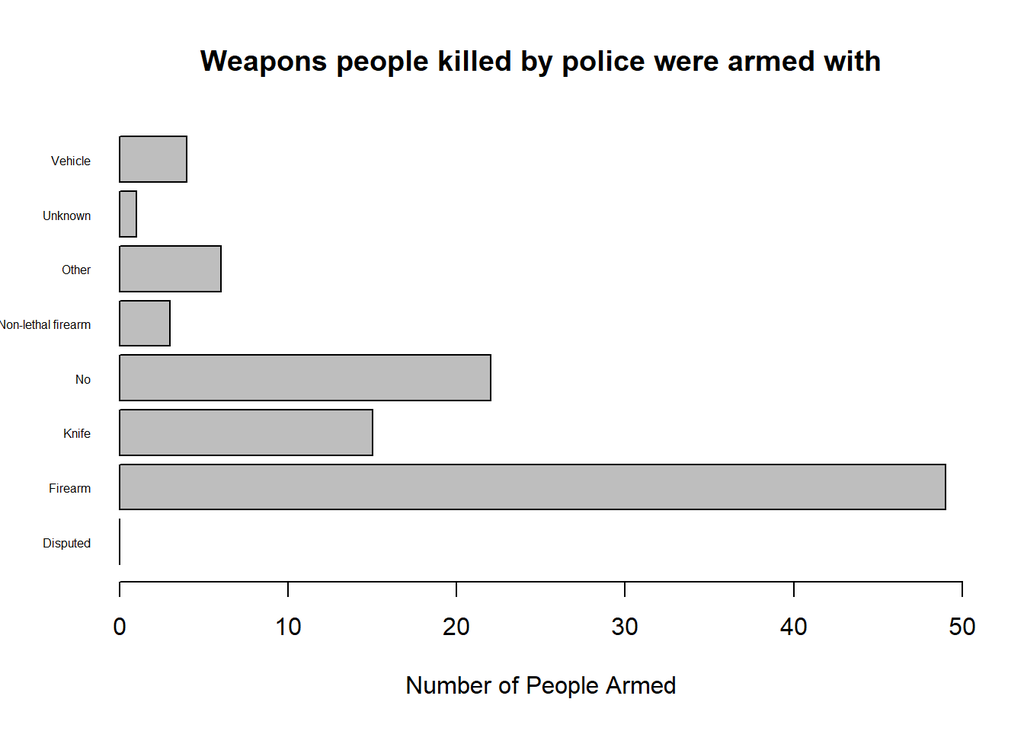

```r
barplot(pct2, horiz=T, xlim = c(0,50) ,las=1,  main = "Weapons people killed by police were armed with", xlab= "Number of People Armed",  cex.names=.5)
```

—

## In addition, I added a bar plot that shows what weapons the people killed by the police were armed with.

| Using dplyr’s distinct() 4 function, we can see the list of all states in the dataset. There are 47 states. |
| --- |

```r
data2 %>%
  distinct(state) %>%
  reactable(bordered = TRUE, striped = TRUE,
          highlight = TRUE, filterable = TRUE,  showPageSizeOptions = TRUE,
          showPagination = TRUE, pageSizeOptions = c(5, 10, 20),
          defaultPageSize = 5)
```

| state |
| --- |
| AL |
| LA |
| WI |
| CA |
| OH |
| AZ |
| TX |
| MI |
| IN |
| TN |

[output cut: 37 more lines]

| I used janitor’s tabyl() function to count how often each state and law enforcement agency shows up. tabyl also calculates the percentage. |
| --- |

```r
data3<-tabyl(data2, state)
data3 %>%
  arrange(desc(n))
```

```
##  state  n     percent
##     CA 74 0.158458244
##     TX 46 0.098501071
##     FL 29 0.062098501
##     AZ 25 0.053533191
##     OK 22 0.047109208
##     GA 16 0.034261242
##     NY 14 0.029978587
##     CO 12 0.025695931
##     IL 11 0.023554604
##     LA 11 0.023554604
##     NJ 11 0.023554604
##     WA 11 0.023554604
##     MD 10 0.021413276
##     MO 10 0.021413276
##     NC 10 0.021413276
##     OH 10 0.021413276
##     MI  9 0.019271949
##     SC  9 0.019271949
##     VA  9 0.019271949
##     AL  8 0.017130621
##     IN  8 0.017130621
##     OR  8 0.017130621
##     KY  7 0.014989293
##     PA  7 0.014989293
##     KS  6 0.012847966
##     MN  6 0.012847966
##     MS  6 0.012847966
##     NE  6 0.012847966
##     TN  6 0.012847966
##     MA  5 0.010706638
##     NM  5 0.010706638
##     UT  5 0.010706638
##     WI  5 0.010706638
##     AR  4 0.008565310
##     HI  4 0.008565310
##     ID  4 0.008565310
##     NV  3 0.006423983
##     AK  2 0.004282655
##     DE  2 0.004282655
##     IA  2 0.004282655
##     MT  2 0.004282655
##     WV  2 0.004282655
##     CT  1 0.002141328
##     DC  1 0.002141328
##     ME  1 0.002141328
##     NH  1 0.002141328
##     WY  1 0.002141328
```

```r
reactable(data3,bordered = TRUE, striped = TRUE,
          highlight = TRUE, filterable = TRUE,  showPageSizeOptions = TRUE,
          showPagination = TRUE, pageSizeOptions = c(10, 25,50),
          defaultPageSize = 10)
```

| state | n | percent |
| --- | --- | --- |
| AK | 2 | 0.00428265524625268 |
| AL | 8 | 0.0171306209850107 |
| AR | 4 | 0.00856531049250535 |
| AZ | 25 | 0.0535331905781585 |
| CA | 74 | 0.158458244111349 |
| CO | 12 | 0.0256959314775161 |
| CT | 1 | 0.00214132762312634 |
| DC | 1 | 0.00214132762312634 |
| DE | 2 | 0.00428265524625268 |
| FL | 29 | 0.0620985010706638 |

[output cut: 37 more lines]

```r
data4<-tabyl(data2, lawenforcementagency)
data4 %>%
  arrange(desc(n))
```

```
##                                                                             lawenforcementagency
##                                                                    Los Angeles Police Department
##                                                          Los Angeles County Sheriff's Department
##                                                                  Oklahoma City Police Department
##                                                                              US Marshals Service
##                                                                     Fort Worth Police Department
##                                                      Indianapolis Metropolitan Police Department
##                                                                       New York Police Department
##                                                                        Phoenix Police Department
##                                                                         Austin Police Department
##                                                                        El Paso Police Department
##                                                                Jefferson Parish Sheriff's Office
##                                                                          New Jersey State Police
##                                                                          Omaha Police Department
##                                                                        Pennsylvania State Police
##                                                            Riverside County Sheriff's Department
##                                                                    San Antonio Police Department
##                                                                  San Francisco Police Department
##                                                                                 US Border Patrol
##                                                                        Anaheim Police Department
##                                                                      Arlington Police Department
##                                                                        Atlanta Police Department
##                                                                         Aurora Police Department
##                                                                    Bakersfield Police Department
##                                                               Baltimore County Police Department
##                                                                      Baltimore Police Department
##                                                                     Cleveland Division of Police
##                                                                    Eaton County Sheriff's Office
##                                                                        Garland Police Department
##                                                                       Gastonia Police Department
##                                                                       Glendale Police Department
##                                                                        Houston Police Department
##                                                                     Kern County Sheriff's Office
##                                                                     Long Beach Police Department
##                                                                      Mansfield Police Department
##                                                                        Medford Police Department
##                                                                        Memphis Police Department
##                                                                    New Orleans Police Department
##                                                               North Charleston Police Department
##                                                                          Oklahoma Highway Patrol
```

[output cut: 701 more lines]

```
##   1 0.002141328
##   1 0.002141328
##   1 0.002141328
##   1 0.002141328
##   1 0.002141328
##   1 0.002141328
##   1 0.002141328
##   1 0.002141328
##   1 0.002141328
##   1 0.002141328
##   1 0.002141328
##   1 0.002141328
##   1 0.002141328
##   1 0.002141328
##   1 0.002141328
```

```r
reactable(data3,bordered = TRUE, striped = TRUE,
          highlight = TRUE, filterable = TRUE,  showPageSizeOptions = TRUE,
          showPagination = TRUE, pageSizeOptions = c(10, 25,50),
          defaultPageSize = 10)
```

| state | n | percent |
| --- | --- | --- |
| AK | 2 | 0.00428265524625268 |
| AL | 8 | 0.0171306209850107 |
| AR | 4 | 0.00856531049250535 |
| AZ | 25 | 0.0535331905781585 |
| CA | 74 | 0.158458244111349 |
| CO | 12 | 0.0256959314775161 |
| CT | 1 | 0.00214132762312634 |
| DC | 1 | 0.00214132762312634 |
| DE | 2 | 0.00428265524625268 |
| FL | 29 | 0.0620985010706638 |

[output cut: 37 more lines]

| Here’s a graph of the data I calculated above. |
| --- |

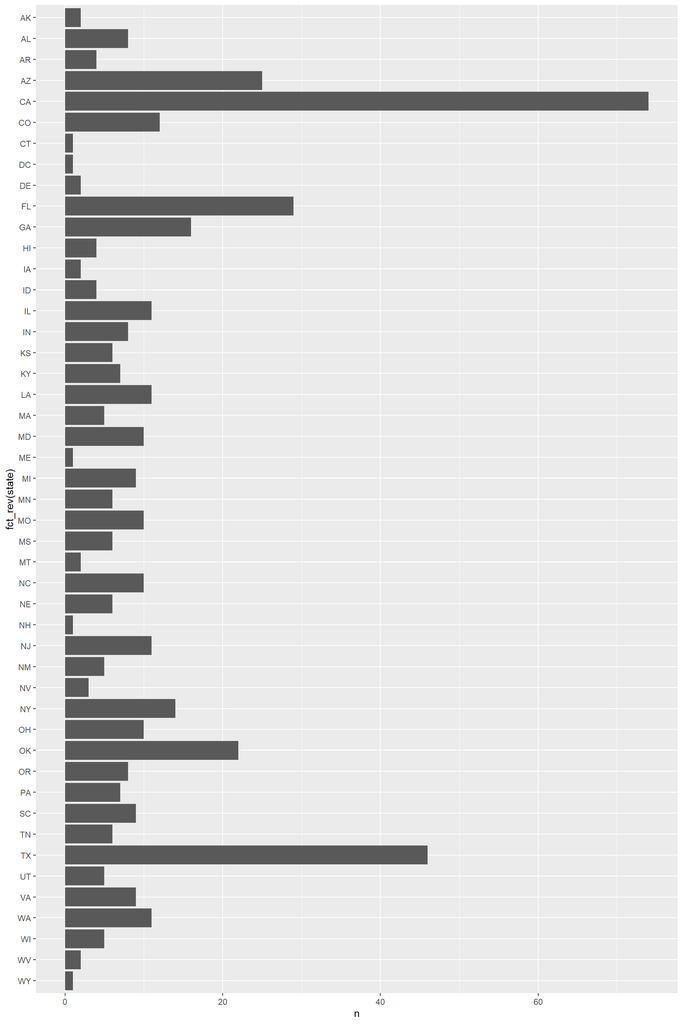

```r
p <- ggplot(data3, aes(x=fct_rev(state), y=n))+
    geom_bar(stat="identity")+ coord_flip()
p
```

In conclusion, California was in 1st with 74 people killed by police in 2015 while Texas came in second with 46 (Los Angeles Police Department also came in 1st with the most people killed by a Law Enforcement Agency). The Weapon the people killed by police were mostly armed with was a firearm. In addition, even though majority of the police killings occurred in neighborhoods that are poorer and blacker, 51% of the people killed were white. To build on this analysis, I would focus on the data we have on income.